# ProsperLoanDataExplanatoryPhase slides

## Effects of Loan Features on the ProsperRating (Alpha).

### Investigation Overview.

In this exploration,I wanted to examine the features of loans that could be used to determine the ProsperRating (Alpha).Features that i mainly focused on were DebtToIncomeRatio,StatedMonthlyIncomes,CurrentlyInGroup,TotalTrades and also LoanStatus.

### Dataset Overview.

This dataset contains 113,937 loans with 81 variables on each loan, including loan amount,borrowerAPR or interest rate, loan status,LoanTerm,borrower income,ProsperRating(Alpha),EmploymentStatus,DebtToIncomeRatio,StatedMonthlyIncome, occupation and many others.

### ProsperRating (Alpha) Distribution

ProsperRating (Alpha) follows a normal distribution, as most of the loans are rated at C, which is the centre of this distribution.Few loans are rated at AA,which is the best rating.

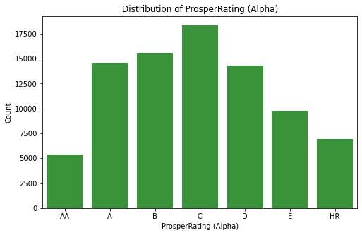

## DebtToIncomeRatio Distribution.

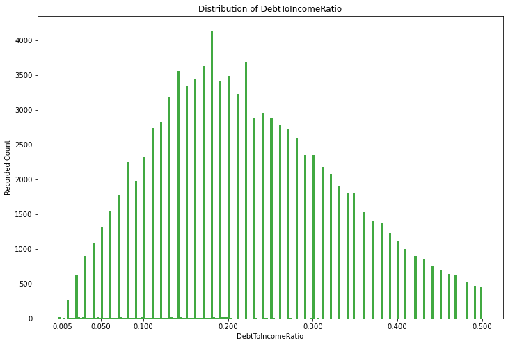

### StatedMonthlyIncome Distribution.

As the income increase from 0 to 2500 to 5000,the loan count also increase.But from 5000 onwards the counts starts to decrease.This implies that most of the borrowers in our dataset receive an average income of 5000.

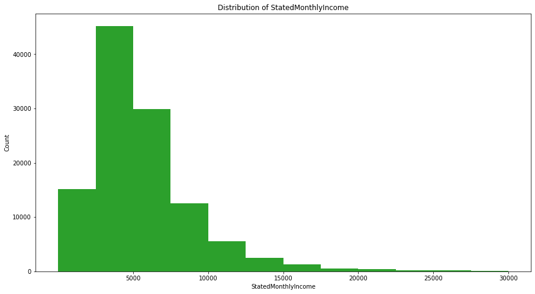

### Relationship between the ProsperRating (Alpha) and DebtToIncomeRatio.

ProsperRating (Alpha) and DebtToIncomeRatio have a negative association with each other. This implies that as the debt to income ratio decreases the prosperrating becomes better.

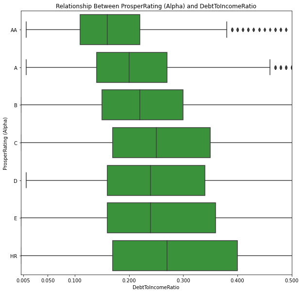

### Relation between ProsperRating (Alpha) and StatedMonthlyIncome.

As the income increases the ratings gets better, thus a positive relationship between the two features.

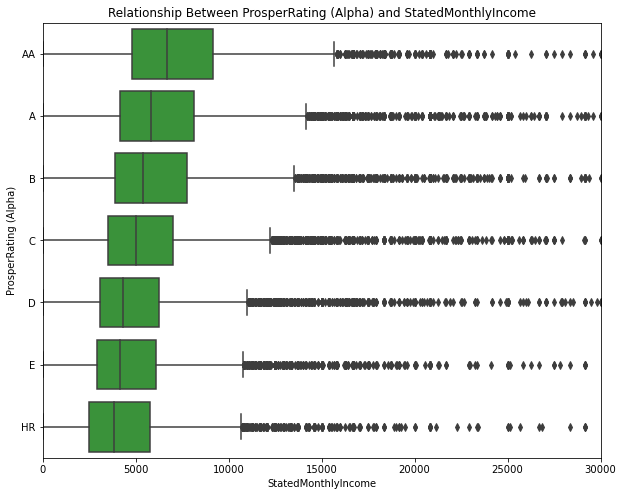

### ProsperRating(Alpha) across StatedMonthlyIncome and CurrentlyInGroup.

An increase in statedmonthlyincomes of borrowers who were in group and those not in group, leads to a better rating.Borrowers nt in groups have a higher amount of income than those in group from rate HR to A.But at AA, those in groups have a higher income than those not in groups.

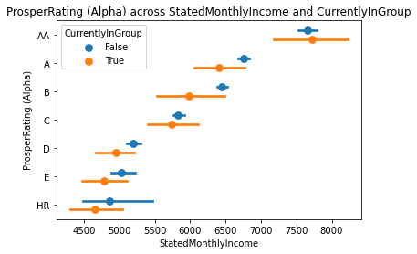

### Relationship of DebtToIncomeRatio and StatedMonthlyIncomes across all the ProspeRating (Alpha)

With the best rating, we see that most points have a lower debt to income ratio and a high amount of income while as the rating becomes bad, we see most datapoints with high debt to income ratio.

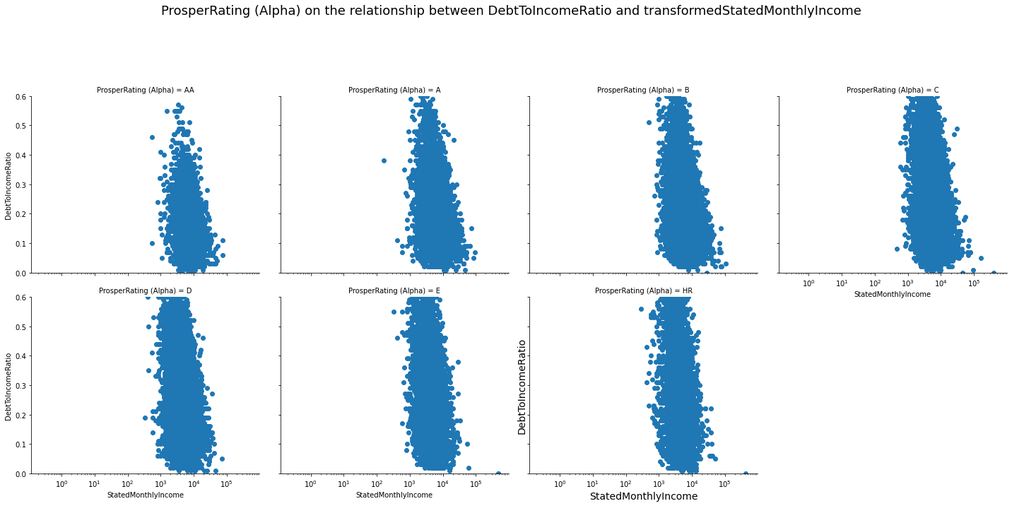